# 📈 Albemarle Stock Trading Strategy

## (Ticker: ALB)

Technical Trading Indicator: Bollinger Bands

October 2025 | Andrew Frohner

# Summary

This content demonstrates how basic a systematic investing strategy can be.

Individual investors and speculators, in general, would like to believe that the investment decisions they make will be profitable. Many investors would also like to feel a greater level of "certainty" around the market they are participating in. A systematic investing strategy that is tested on historical data can provide a more certainty to individuals, even if it merely incremental.

The systematic trading strategy presented here is based on a technical indicator called Bollinger Bands. Bollinger Bands are a type of statistical chart characterizing the prices and volatility over time of a financial instrument or commodity, using a formulaic method propounded by John Bollinger in the 1980s.

This strategy is not empirical, but it does rely on economic and probabilistic principles. The strategy is based on the idea that prices tend to revert to the mean over time. When the price of a stock moves significantly away from its average price, it is likely to revert back to the average price over time. Bollinger Bands are used to identify these significant price movements. The strategy involves buying the stock when the price moves below the lower Bollinger Band and selling the stock when the price moves above the upper Bollinger Band.

# Data Import and Setup

# Historical Stock Price Analysis

```python
# Fetch historical stock data
import yfinance as yf
data = yf.download('ALB', start='2010-01-01', end='2025-10-10')


# Flatten the MultiIndex columns
data.columns = [col[0] if isinstance(col, tuple) else col for col in data.columns]
# Now data['Close'] will be a Series!

# Display the first few rows of the data
```

```
[*********************100%***********************]  1 of 1 completed
```

```
<class 'pandas.core.series.Series'>
<class 'pandas.core.series.Series'>
(3967,)
Index(['Close', 'High', 'Low', 'Open', 'Volume'], dtype='object')
```

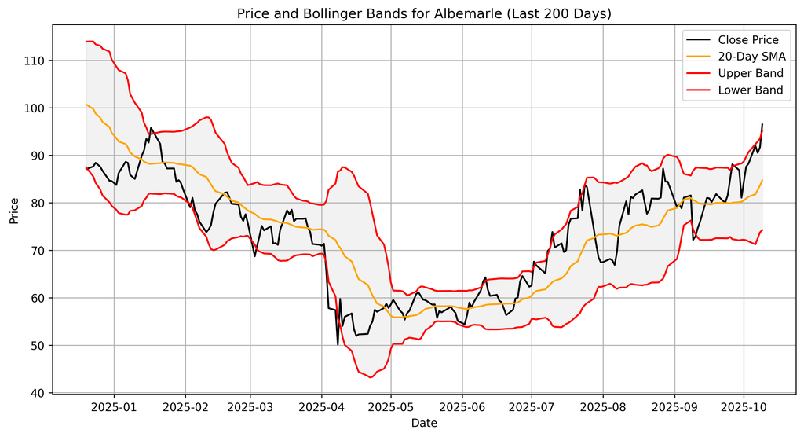

```python
data.head()
print(type(data['Close']))

# Convert to a series
close = data['Close']
open = data['Open']
high = data['High']
low = data['Low']
volume = data['Volume']

print(type(data['Close']))
print(data['Close'].shape)
type(close)

print(data.columns)


## Calculate Bollinger Bands
window = 20
std = 2

data['SMA'] = close.rolling(window=window).mean()
data['Upper'] = data['SMA'] + std *  close.rolling(window=window).std()
data['Lower'] = data['SMA'] - std * close.rolling(window=window).std()

# Plot the closing price and Bollinger Bands
# Only plot the last 200 days for clarity
# Slice all data to last 200 days
last_200_data = data.tail(200)  # Gets last 200 rows
last_200_close = close.tail(200)

import matplotlib.pyplot as plt

plt.figure(figsize=(14, 7))
plt.plot(last_200_close.index, last_200_close, label='Close Price', color='black')
plt.plot(last_200_data.index, last_200_data['SMA'], label='20-Day SMA', color='orange')
plt.plot(last_200_data.index, last_200_data['Upper'], label='Upper Band', color='red')
plt.plot(last_200_data.index, last_200_data['Lower'], label='Lower Band', color='red')
plt.fill_between(last_200_data.index, last_200_data['Lower'], last_200_data['Upper'], color='gray', alpha=0.1)
plt.title('Price and Bollinger Bands for Albemarle (Last 200 Days)')
plt.xlabel('Date')
plt.ylabel('Price')
plt.legend()
plt.grid()

#Hide the plot to prevent display in notebook
plt.close()

import matplotlib.pyplot as plt
from IPython.display import Image, display

# Create a new figure and axes
fig0, ax0 = plt.subplots(figsize=(12, 6))
# Plot on the axes
ax0.plot(last_200_close.index, last_200_close, label='Close Price', color='black')
ax0.plot(last_200_data.index, last_200_data['SMA'], label='20-Day SMA', color='orange')
ax0.plot(last_200_data.index, last_200_data['Upper'], label='Upper Band', color='red')
ax0.plot(last_200_data.index, last_200_data['Lower'], label='Lower Band', color='red')
ax0.fill_between(last_200_data.index, last_200_data['Lower'], last_200_data['Upper'], color='gray', alpha=0.1)
ax0.set_title('Price and Bollinger Bands for Albemarle (Last 200 Days)')
ax0.set_xlabel('Date')
ax0.set_ylabel('Price')
ax0.legend()
ax0.grid()

# Save the figure before closing
fig0.savefig('bollinger_bands_alb.png', dpi=300, bbox_inches='tight')
# Close the figure to prevent display in notebook
plt.close(fig0)
# Display the saved image
display(Image(filename='bollinger_bands_alb.png'))
```

The Historical Price data for Albemarle over the past 200 days is shown above.

The red skwiggly lines above and below the black line are the "Bollinger Bands". Each band represents the stock price of Albemarle if it deviates from its 20-day moving average price by 2 standard deviations. In theory, 95% of the price action should occur within these bands when we assume a normal distribution.

A speculator might trade on this theory. Thinking that when the price of Albemarle closes below the lower band... it will rise back to it's moving average. Conversely, when the price of Albemarle closes above the upper band... it will fall back to it's moving average.

This is the basis of the trading strategy we will backtest below.

# Backtesting Mean reversion using Bollinger Bands

This strategy goes long when the price closes below the lower band, and closes that position when the price reverts to the 20-day SMA. It goes short when the price closes above the upper band, and closes that position when the price reverts to the 20-day SMA. If you are trading this strategy, you will not capture extreme price movements between the bands, but you will capture the mean reversion moves that occur most of the time.

The Backtest results are shown below:

If you traded this strategy for the last 15 years, would you have made 62% on your money, and approx. 3% annualized. You would have executed 282 trades. Some of the performance metrics (Calmar Ratio , Sharpe Ratio, Sortino Ratio) suggest that this is a high risk strategy. Where negative returns are large relative to positive returns.

```python
import warnings
warnings.filterwarnings('ignore')
import matplotlib.pyplot as plt
import pandas as pd
import bt
#Define Price for Backtesting strategy 1
price = data['Close']

# Create bt_data ONCE with price column
bt_data = pd.DataFrame({
    'ALB': data['Close']  # Price data with ticker name
}).dropna()

import numpy as np
import pandas as pd

bt_data['Signal'] = 0.0  # Start neutral

# Entry/exit logic
long_entry = (bt_data['ALB'] < data['Lower'].reindex(bt_data.index))
long_exit = (bt_data['ALB'] > data['SMA'].reindex(bt_data.index))
short_entry = (bt_data['ALB'] > data['Upper'].reindex(bt_data.index))
short_exit = (bt_data['ALB'] < data['SMA'].reindex(bt_data.index))

# Use a stateful approach to avoid conflicting signals
position = 0  # 1 for long, -1 for short, 0 for flat
signals = []

for i in range(len(bt_data)):
    if position == 0:
        if long_entry.iloc[i]:
            position = 1
        elif short_entry.iloc[i]:
            position = -1
    elif position == 1:
        if long_exit.iloc[i]:
            position = 0
    elif position == -1:
        if short_exit.iloc[i]:
            position = 0
    signals.append(position)

bt_data['Signal'] = signals

# Separate the price and signal columns for clarity
price_data = bt_data[['ALB']].copy()
#Create signal DataFrame with SAME column as price
signal_data = pd.DataFrame(index=bt_data.index)
signal_data['ALB'] = bt_data['Signal']

import bt
# Create strategy
strategy1 = bt.Strategy('Bollinger_Bands_1', [bt.algos.RunWeekly(),
    bt.algos.SelectAll(),
    bt.algos.WeighTarget(signal_data),  # Signal column now exists
    bt.algos.Rebalance()
])
# Run backtest
backtest1 = bt.Backtest(strategy1, price_data, initial_capital=10000)
result1 = bt.run(backtest1)
```

# Backtest Results ⬇️

```python
import bt
result1.display()

# Count trades
num_trades = (bt_data['Signal'].diff() != 0).sum()
print(f"Number of trades executed: {num_trades}")

# Plot the results
result1.plot(title='How your Money was Gained/Lost using this Strategy', figsize=(12, 6))

# Close the plot to prevent display in notebook
plt.close()
```

```
Stat                 Bollinger_Bands_1
-------------------  -------------------
Start                2010-01-03
End                  2025-10-09
Risk-free rate       0.00%

Total Return         62.81%
Daily Sharpe         0.25
Daily Sortino        0.40
CAGR                 3.14%
Max Drawdown         -59.72%
Calmar Ratio         0.05

MTD                  -16.13%
3m                   -9.11%
6m                   -15.83%
YTD                  16.52%
1Y                   21.59%
3Y (ann.)            18.30%
5Y (ann.)            -0.02%
10Y (ann.)           3.01%
Since Incep. (ann.)  3.14%

Daily Sharpe         0.25
Daily Sortino        0.40
Daily Mean (ann.)    7.91%
Daily Vol (ann.)     31.10%
Daily Skew           0.45
Daily Kurt           12.55
Best Day             19.08%
Worst Day            -13.65%

Monthly Sharpe       0.25
Monthly Sortino      0.42
Monthly Mean (ann.)  6.74%
Monthly Vol (ann.)   26.89%
Monthly Skew         -0.17
Monthly Kurt         0.58
Best Month           20.97%
Worst Month          -24.16%

Yearly Sharpe        0.36
Yearly Sortino       0.60
Yearly Mean          6.27%
Yearly Vol           17.55%
Yearly Skew          -1.03
Yearly Kurt          1.06
Best Year            32.33%
Worst Year           -33.93%

Avg. Drawdown        -12.76%
Avg. Drawdown Days   248.36
Avg. Up Month        6.31%
Avg. Down Month      -5.12%
Win Year %           73.33%
Win 12m %            67.60%
Number of trades executed: 282
```

```python
import matplotlib.pyplot as plt
from IPython.display import Image, display

# Create a new figure and axes
fig, ax = plt.subplots(figsize=(12, 6))

# Plot on the axes
result1.plot(title='How your Money was Gained/Lost using this Strategy', ax=ax)

# Save the figure before closing
fig.savefig('bollinger_bands_backtest1_alb.png', dpi=300, bbox_inches='tight')

# Close the figure to prevent display in notebook
plt.close(fig)
```

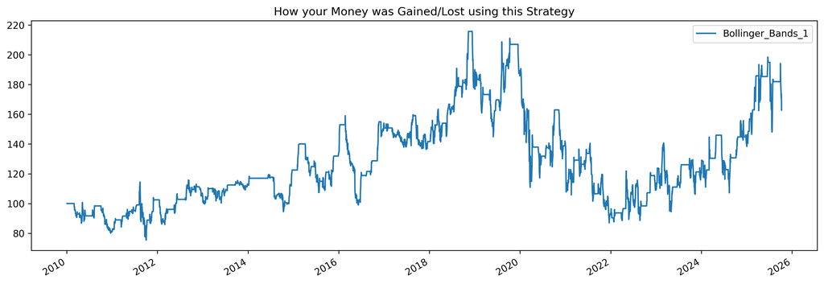

```python
# Display the saved image
display(Image(filename='bollinger_bands_backtest1_alb.png'))
```

# Backtesting Extreme Price moves using Bollinger Bands

A speculator may know that the equity asset class is, in general, more volatile than fixed income or commodities. They may use the Bollinger Bands to trade extreme price movements.

A second Bollinger Bands strategy is backtested below. This strategy goes long when the price closes below the lower band, and only closes that position when the price breaks above the upper band.

It goes short when the price closes above the upper band, and only closes that position when the price falls back below the lower band. Aiming to capture the full volatility around the 20 day moving average.

The Backtest results are shown below:

If you had $10,000 and traded this strategy for the last 15 years, would you have made 34% on your money, and less than 2% annualized. You would have executed 450 trades. Some of the performance metrics (Calmar Ratio , Sharpe Ratio, Sortino Ratio) suggest that this is just as risky as the mean reversion method of trading the bollinger bands. Simiarly, negative returns here are larger relative to positive returns.

```python
#Define Price for Backtesting strategy
price = data['Close']

# Create bt_data ONCE with price column
bt_data2 = pd.DataFrame({
    'ALB': data['Close']  # Price data with ticker name
}).dropna()

# Add Signal column to SAME DataFrame (don't recreate bt_data!)
bt_data2['Signal'] = 0.0

# Generate Bollinger Band signals
buy_condition = bt_data2['ALB'] < data['Lower'].reindex(bt_data2.index)
sell_condition = bt_data2['ALB'] > data['Upper'].reindex(bt_data2.index)

bt_data2.loc[buy_condition, 'Signal'] = 1.0   # Long
bt_data2.loc[sell_condition, 'Signal'] = -1.0  # Short

# Forward-fill signals to maintain positions
bt_data2['Signal'] = bt_data2['Signal'].ffill().fillna(0.0)

# Separate the price and signal columns for clarity
price_data = bt_data2[['ALB']].copy()

#Create signal DataFrame with SAME column as price
signal_data = pd.DataFrame(index=bt_data2.index)
signal_data['ALB'] = bt_data2['Signal']
```

```python
import bt
# Create strategy
strategy2 = bt.Strategy('Bollinger_Bands_2', [bt.algos.RunWeekly(),
    bt.algos.SelectAll(),
    bt.algos.WeighTarget(signal_data),  # Signal column now exists
    bt.algos.Rebalance()
])

# Run backtest
backtest2 = bt.Backtest(strategy2, price_data, initial_capital=10000)
result2 = bt.run(backtest2)
```

# Backtest Results ⬇️

```python
import bt
result2.display()
# Count trades
num_trades = (bt_data2['Signal'].diff() != 0).sum()
print(f"Number of trades executed: {num_trades}")
```

```
Stat                 Bollinger_Bands_2
-------------------  -------------------
Start                2010-01-03
End                  2025-10-09
Risk-free rate       0.00%

Total Return         33.76%
Daily Sharpe         0.20
Daily Sortino        0.29
CAGR                 1.86%
Max Drawdown         -57.26%
Calmar Ratio         0.03

MTD                  0.00%
3m                   0.00%
6m                   -5.08%
YTD                  0.77%
1Y                   9.00%
3Y (ann.)            -0.88%
5Y (ann.)            -1.94%
10Y (ann.)           -1.37%
Since Incep. (ann.)  1.86%

Daily Sharpe         0.20
Daily Sortino        0.29
Daily Mean (ann.)    2.99%
Daily Vol (ann.)     15.15%
Daily Skew           0.80
Daily Kurt           99.73
Best Day             19.05%
Worst Day            -13.68%

Monthly Sharpe       0.20
Monthly Sortino      0.30
Monthly Mean (ann.)  2.93%
Monthly Vol (ann.)   14.42%
Monthly Skew         -1.02
Monthly Kurt         18.95
Best Month           20.40%
Worst Month          -29.80%

Yearly Sharpe        0.23
Yearly Sortino       0.33
Yearly Mean          3.87%
Yearly Vol           17.18%
Yearly Skew          -1.50
Yearly Kurt          5.03
Best Year            32.09%
Worst Year           -45.91%

Avg. Drawdown        -5.76%
Avg. Drawdown Days   212.08
Avg. Up Month        4.26%
Avg. Down Month      -0.98%
Win Year %           80.00%
Win 12m %            66.48%
Number of trades executed: 450
```

```python
import matplotlib.pyplot as plt
from IPython.display import Image, display

# Create a new figure and axes
fig2, ax2 = plt.subplots(figsize=(12, 6))

# Plot on the axes
result2.plot(title='How your Money was Gained/Lost using this Strategy', ax=ax2)

# Save the figure before closing
fig2.savefig('bollinger_bands_backtest2_alb.png', dpi=300, bbox_inches='tight')

# Close the figure to prevent display in notebook
plt.close(fig2)
```

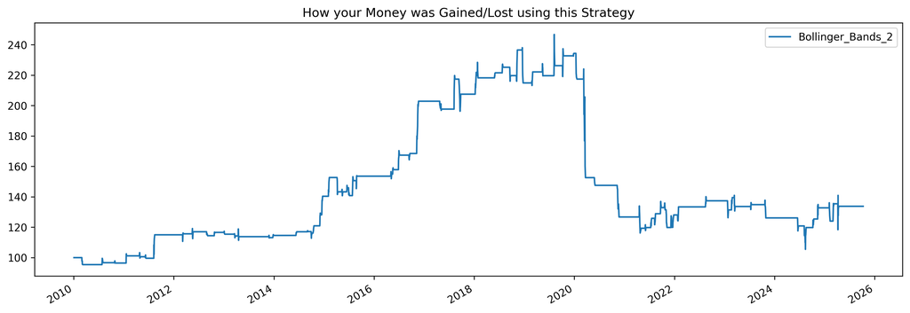

```python
# Display the saved image
display(Image(filename='bollinger_bands_backtest2_alb.png'))
```

## Conclusions and Recommendations

### Key Findings 🔍:

1. **Strategy Performance**: Both Bollinger Bands strategies demonstrated the potential for profit over a 15-year period, with Strategy 1 (mean reversion) yielding a higher overall return compared to Strategy 2 (extreme price moves).
2. **Risk Metrics**: Both strategies exhibited high-risk characteristics, as indicated by their Calmar, Sharpe, and Sortino ratios. This suggests that while profits were achievable, the strategies also exposed investors to significant downside risk.
3. **Trade Frequency**: Strategy 2 executed more trades than Strategy 1, which could lead to higher transaction costs and slippage, potentially eroding profits.

### Strategic Recommendations 📝:

1. **Portfolio Integration**: Consider this strategy as part of a diversified approach
2. **Risk Management**: Implement stop-loss mechanisms for enhanced protection
3. **Parameter Optimization**: Test different window sizes and standard deviation multipliers
4. **Market Conditions**: Monitor performance across different market regimes

*Analysis completed: October 2025 | Andrew F*